# Centrální limitní věta - opakování a rozšíření

## CLT - shrnutí

1. Co říká CLT?
2. Co je to standardní chyba?
3. Co je to konfidenční interval?
4. Jak na základě CLT počítáme konfidenční interval?

## Jak na základě CLT počítáme konfidenční interval?

1. Provedeme bodový odhad (k tomu CLT nepotřebujeme).
2. Od něj odečteme (spodní hranice) a přičteme (horní hranice) “chybu odhadu” (margin of error).
3. Chyba odhadu? Na základě CLT pomocí z-skoŕu normálního rozdělení

\[ CI = \bar{X} \mp z*SE \]

## Kde se bere hodnota z?

Z-skór normálního rozdělení pro \(\alpha/2\), kde:

\[ \alpha = hladina\;významnosti = (100 - hladina\;spolehlivosti)/100 \]

- Například pro 95% interval spolehlivosti je hladina spolehlivosti 95 %
- Tedy \(\alpha = 0,05\) a \(\alpha/2 = 0,025\)

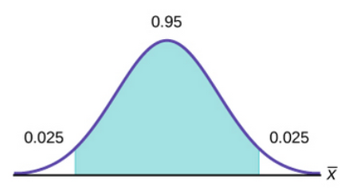

[Zdroj obrázku](https://courses.lumenlearning.com/odessa-introstats1-1/chapter/a-single-population-mean-using-the-normal-distribution/)

Hledáme tedy Z(0.025), např.v Excelu: =NORM.INV(0,975;0;1), což vrátí hodnotu 1,96.

## Chyba odhadu pomocí Studentova t rozdělení (NADSTAVBA)

Pokud má náhodná proměnná normální rozdělení, pak konfidenční interval získáme dle následujícího vzorce:

\[ CI = \bar{X} \mp t * SE, \]

kde samozřejmě opět platí, že:

\[ SE = \frac{s}{\sqrt{n}} \]

t je hodnota t-rozdělení (vyčteme z tabulek) pro daný počet stupňů volnosti (degrees of freedom). DF = n - 1.

## Co ovlivňuje šíři konfidenčního intervalu?

- Počet pozorování ve výběrovém souboru (N)
- Variabilita v populaci
- Požadovaná úroveň spolehlivosti

## Cvičení: Jak konstruovat interval spolehlivosti pro binární proměnnou?

Návrat k příkladu příznivců trvalé hybridní výuky.

- X … proměnná, zda příznivec hybridní výuky (1), nebo ne (0). Pr(X=příznivec) = \(p_X\).
- Výběrový soubor n = 200
- Počet příznivců ve výběrovém souboru = 40
- OTÁZKA: Jaký je bodový a intervalový odhad (90% konfidenční interval) hodnoty \(p_X\)?

Doporučený postup:

1. Jakou pravděpodobnostní distribuci má proměnná X?
2. Jak z pozorovaných dat nalezneme bodový odhad očekávané hodnoty této distribuce?
3. Jak nalezneme rozptyl této distribuce?
4. Jak směrodatnou ochylku?
5. Jakou pravděpodobnostní distribuci má bodový odhad očekávané hodnoty? Proč?
6. Jaká je směrodatná odchylka pravděpodobnostní distribuce bodového odhadu očekávané hodnoty?
7. Jaká je Z-hodnota pro 90% konfidenční interval?

## Co je to vlastně pravděpodobnost?

## Co je to vlastně pravděpodobnost?

Paradox: experti se shodnou na “matematice” pravděpodobnosti, ale neshodnou se na tom, co to pravděpodobnost vlastně je.

1. **Klasická definice**: Poměr počtu jevů “úspěšných” dělený celkovým počtem možných jevů za předpokladu, že všechny jevy jsou stejně pravděpodobné.
2. **Frekventistická definice**: Výskyt jevu v nekonečné sérii stejných experimentů. Jádro mainstreamové statistiky.
3. **Subjektivní pravděpodobnost**: Úsudek konkrétní osoby o konkrétní situaci založený na informacích, které má tato osoba k dispozici. Lze interpretovat jako sázkový kurz (u malých sázek). Jádro bayesovské statistiky.

## Jak interpretovat pravděpodobnost?

Pr(na minci padne hlava) = 0.5

- Frekventisté: Pokud bychom mnohokrát hodili touto mincí, v 50 % by padla hlava.
- Bayesiánci: Na to, že padně hlava, bych vsadil s kurzem 1:1.

## Jak se liší jejich přístup ke statistice?

### Populační parametr

- **Frekventisté**: Populační parametr je jedna fixní (většinou neznámá) hodnota.
- **Bayesiánci**: Populační parametr je hodnota, která se s určitou pravděpodobností vyskytuje v daném intervalu.

### Intervalové odhady

- **Frekventisté**: Interval spolehlivost je interval, který bude napříč velkým počtem vzorků obsahovat skutečnou hodnotu (populační parametr) s danou pravděpodobností.
- **Bayesiánci**: Interval kredibility je interval, který s danou pravděpodobností obsahuje skutečnou hodnotu (populační parametr).

## Frekventisté vs. Bayesiánci - konkrétní příklad

Jak interpretovat, že podpora politické strany má 95% interval spolehlivosti <26 %; 29 %>?

- **Frekventisté**: Pokud bychom opakovaně tahali velké množství vzorků stejné velikosti z populace a pro každý z nich spočítali 95% interval spolehlivosti, 95 % z nich by obsahovalo skutečnou hodnotu podpory strany. Rozpětí těchto intervalů by mělo cca 3 procentní body.
- **Bayesiánci**: Na 95 % je skutečná podpora strany něco mezi 26 a 29 procenty